# Ford GoBike System Data Exploration

## Introduction

> Ford GoBike System Data: This data set includes information about individual rides made in a bike-sharing system covering the greater San Francisco Bay area.

## Preliminary Wrangling

```python
# import all packages and set plots to be embedded inline
import numpy as np
import pandas as pd
import matplotlib.pyplot as plt
import seaborn as sb

%matplotlib inline
```

> Load in your dataset and describe its properties through the questions below. Try and motivate your exploration goals through this section.

```python
#load in the datasets into the pandas dataframe , print statistics
ford = pd.read_csv('201902-fordgobike-tripdata.csv')
```

```python
#high-level overview of the data shape and composition before dropping missing values
print(ford.shape)
print(ford.dtypes)
print(ford.head(10))
```

```
(183412, 16)
duration_sec                 int64
start_time                  object
end_time                    object
start_station_id           float64
start_station_name          object
start_station_latitude     float64
start_station_longitude    float64
end_station_id             float64
end_station_name            object
end_station_latitude       float64
end_station_longitude      float64
bike_id                      int64
user_type                   object
member_birth_year          float64
member_gender               object
bike_share_for_all_trip     object
dtype: object
   duration_sec                start_time                  end_time  \
0         52185  2019-02-28 17:32:10.1450  2019-03-01 08:01:55.9750
1         42521  2019-02-28 18:53:21.7890  2019-03-01 06:42:03.0560
2         61854  2019-02-28 12:13:13.2180  2019-03-01 05:24:08.1460
3         36490  2019-02-28 17:54:26.0100  2019-03-01 04:02:36.8420
4          1585  2019-02-28 23:54:18.5490  2019-03-01 00:20:44.0740
5          1793  2019-02-28 23:49:58.6320  2019-03-01 00:19:51.7600
6          1147  2019-02-28 23:55:35.1040  2019-03-01 00:14:42.5880
7          1615  2019-02-28 23:41:06.7660  2019-03-01 00:08:02.7560
8          1570  2019-02-28 23:41:48.7900  2019-03-01 00:07:59.7150
9          1049  2019-02-28 23:49:47.6990  2019-03-01 00:07:17.0250

   start_station_id                                start_station_name  \
0              21.0  Montgomery St BART Station (Market St at 2nd St)
1              23.0                     The Embarcadero at Steuart St
2              86.0                           Market St at Dolores St
3             375.0                           Grove St at Masonic Ave
4               7.0                               Frank H Ogawa Plaza
5              93.0                      4th St at Mission Bay Blvd S
6             300.0                              Palm St at Willow St
7              10.0                        Washington St at Kearny St
8              10.0                        Washington St at Kearny St
```

[output cut: 34 more lines]

```
7            -122.421025     6329  Subscriber             1989.0
8            -122.421025     6548  Subscriber             1988.0
9            -122.421339     6488  Subscriber             1992.0

  member_gender bike_share_for_all_trip
0          Male                      No
1           NaN                      No
2          Male                      No
3         Other                      No
4          Male                     Yes
5          Male                      No
6        Female                      No
7          Male                      No
8         Other                      No
9          Male                      No
```

```python
ford.isnull().sum()
```

```
duration_sec                  0
start_time                    0
end_time                      0
start_station_id            197
start_station_name          197
start_station_latitude        0
start_station_longitude       0
end_station_id              197
end_station_name            197
end_station_latitude          0
end_station_longitude         0
bike_id                       0
user_type                     0
member_birth_year          8265
member_gender              8265
bike_share_for_all_trip       0
dtype: int64
```

```python
ford.duplicated().sum()
```

```
0
```

### Quality Issues

- Completeness : missing `start_station_id`,`start_station_name`,`end_station_id`,`end_station_name`,`member_birth_year`,`member_gender` values.
- Validity: incorrect `start_time`,`end_time`, `member_gender`,`bike_share_for_all_trip`,`user_type` data type.

## Data Cleaning

### Define

- remove all missing values
- change the `start_time,end_time`, `member_gender`,`bike_share_for_all_trip`,`user_type` column data types to datetime and categories respectively

### Code

```python
# make a copy of the data
ford_clean = ford.copy()
```

```python
#drop all missing values
ford_clean.dropna(inplace=True)
```

```python
# change the columns to datetime

ford_clean.iloc[:,1:3] = ford_clean.iloc[:,1:3].apply(pd.to_datetime,errors='coerce')

#change columns to category

dtype = { 'user_type':'category',
         'member_gender':'category',
         'bike_share_for_all_trip':'category'

}
ford_clean = ford_clean.astype(dtype)
```

```python
#create age column
ford_clean['age'] = 2019 - ford_clean.member_birth_year
ford_clean.age.head()

# create age bin
med_age =ford_clean.age.median()
ford_clean['age_group'] = np.where(ford_clean['age'] > med_age, 'Adults', 'Young')

#check
ford_clean[ford_clean['age'] > med_age].head()
```

|  | duration_sec | start_time | end_time | start_station_id | start_station_name | start_station_latitude | start_station_longitude | end_station_id | end_station_name | end_station_latitude | end_station_longitude | bike_id | user_type | member_birth_year | member_gender | bike_share_for_all_trip | age | age_group |
| --- | --- | --- | --- | --- | --- | --- | --- | --- | --- | --- | --- | --- | --- | --- | --- | --- | --- | --- |
| 0 | 52185 | 2019-02-28 17:32:10.145 | 2019-03-01 08:01:55.975 | 21.0 | Montgomery St BART Station (Market St at 2nd St) | 37.789625 | -122.400811 | 13.0 | Commercial St at Montgomery St | 37.794231 | -122.402923 | 4902 | Customer | 1984.0 | Male | No | 35.0 | Adults |
| 2 | 61854 | 2019-02-28 12:13:13.218 | 2019-03-01 05:24:08.146 | 86.0 | Market St at Dolores St | 37.769305 | -122.426826 | 3.0 | Powell St BART Station (Market St at 4th St) | 37.786375 | -122.404904 | 5905 | Customer | 1972.0 | Male | No | 47.0 | Adults |
| 4 | 1585 | 2019-02-28 23:54:18.549 | 2019-03-01 00:20:44.074 | 7.0 | Frank H Ogawa Plaza | 37.804562 | -122.271738 | 222.0 | 10th Ave at E 15th St | 37.792714 | -122.248780 | 4898 | Subscriber | 1974.0 | Male | Yes | 45.0 | Adults |
| 5 | 1793 | 2019-02-28 23:49:58.632 | 2019-03-01 00:19:51.760 | 93.0 | 4th St at Mission Bay Blvd S | 37.770407 | -122.391198 | 323.0 | Broadway at Kearny | 37.798014 | -122.405950 | 5200 | Subscriber | 1959.0 | Male | No | 60.0 | Adults |
| 6 | 1147 | 2019-02-28 23:55:35.104 | 2019-03-01 00:14:42.588 | 300.0 | Palm St at Willow St | 37.317298 | -121.884995 | 312.0 | San Jose Diridon Station | 37.329732 | -121.901782 | 3803 | Subscriber | 1983.0 | Female | No | 36.0 | Adults |

### Test

```python
#high-level overview of the data shape and composition after cleaning
print(ford_clean.shape)
print(ford_clean.dtypes)
print(ford_clean.head(10))
```

```
(174952, 18)
duration_sec                        int64
start_time                 datetime64[ns]
end_time                   datetime64[ns]
start_station_id                  float64
start_station_name                 object
start_station_latitude            float64
start_station_longitude           float64
end_station_id                    float64
end_station_name                   object
end_station_latitude              float64
end_station_longitude             float64
bike_id                             int64
user_type                        category
member_birth_year                 float64
member_gender                    category
bike_share_for_all_trip          category
age                               float64
age_group                          object
dtype: object
    duration_sec              start_time                end_time  \
0          52185 2019-02-28 17:32:10.145 2019-03-01 08:01:55.975
2          61854 2019-02-28 12:13:13.218 2019-03-01 05:24:08.146
3          36490 2019-02-28 17:54:26.010 2019-03-01 04:02:36.842
4           1585 2019-02-28 23:54:18.549 2019-03-01 00:20:44.074
5           1793 2019-02-28 23:49:58.632 2019-03-01 00:19:51.760
6           1147 2019-02-28 23:55:35.104 2019-03-01 00:14:42.588
7           1615 2019-02-28 23:41:06.766 2019-03-01 00:08:02.756
8           1570 2019-02-28 23:41:48.790 2019-03-01 00:07:59.715
9           1049 2019-02-28 23:49:47.699 2019-03-01 00:07:17.025
10           458 2019-02-28 23:57:57.211 2019-03-01 00:05:35.435

    start_station_id                                start_station_name  \
0               21.0  Montgomery St BART Station (Market St at 2nd St)
2               86.0                           Market St at Dolores St
3              375.0                           Grove St at Masonic Ave
4                7.0                               Frank H Ogawa Plaza
5               93.0                      4th St at Mission Bay Blvd S
6              300.0                              Palm St at Willow St
7               10.0                        Washington St at Kearny St
```

[output cut: 36 more lines]

```
8             -122.421025     6548  Subscriber             1988.0
9             -122.421339     6488  Subscriber             1992.0
10            -122.415929     5318  Subscriber             1996.0

   member_gender bike_share_for_all_trip   age age_group
0           Male                      No  35.0    Adults
2           Male                      No  47.0    Adults
3          Other                      No  30.0     Young
4           Male                     Yes  45.0    Adults
5           Male                      No  60.0    Adults
6         Female                      No  36.0    Adults
7           Male                      No  30.0     Young
8          Other                      No  31.0     Young
9           Male                      No  27.0     Young
10        Female                     Yes  23.0     Young
```

```python
#checks missing values
ford_clean.isnull().sum()
```

```
duration_sec               0
start_time                 0
end_time                   0
start_station_id           0
start_station_name         0
start_station_latitude     0
start_station_longitude    0
end_station_id             0
end_station_name           0
end_station_latitude       0
end_station_longitude      0
bike_id                    0
user_type                  0
member_birth_year          0
member_gender              0
bike_share_for_all_trip    0
age                        0
age_group                  0
dtype: int64
```

```python
ford_clean.head()
```

|  | duration_sec | start_time | end_time | start_station_id | start_station_name | start_station_latitude | start_station_longitude | end_station_id | end_station_name | end_station_latitude | end_station_longitude | bike_id | user_type | member_birth_year | member_gender | bike_share_for_all_trip | age | age_group |
| --- | --- | --- | --- | --- | --- | --- | --- | --- | --- | --- | --- | --- | --- | --- | --- | --- | --- | --- |
| 0 | 52185 | 2019-02-28 17:32:10.145 | 2019-03-01 08:01:55.975 | 21.0 | Montgomery St BART Station (Market St at 2nd St) | 37.789625 | -122.400811 | 13.0 | Commercial St at Montgomery St | 37.794231 | -122.402923 | 4902 | Customer | 1984.0 | Male | No | 35.0 | Adults |
| 2 | 61854 | 2019-02-28 12:13:13.218 | 2019-03-01 05:24:08.146 | 86.0 | Market St at Dolores St | 37.769305 | -122.426826 | 3.0 | Powell St BART Station (Market St at 4th St) | 37.786375 | -122.404904 | 5905 | Customer | 1972.0 | Male | No | 47.0 | Adults |
| 3 | 36490 | 2019-02-28 17:54:26.010 | 2019-03-01 04:02:36.842 | 375.0 | Grove St at Masonic Ave | 37.774836 | -122.446546 | 70.0 | Central Ave at Fell St | 37.773311 | -122.444293 | 6638 | Subscriber | 1989.0 | Other | No | 30.0 | Young |
| 4 | 1585 | 2019-02-28 23:54:18.549 | 2019-03-01 00:20:44.074 | 7.0 | Frank H Ogawa Plaza | 37.804562 | -122.271738 | 222.0 | 10th Ave at E 15th St | 37.792714 | -122.248780 | 4898 | Subscriber | 1974.0 | Male | Yes | 45.0 | Adults |
| 5 | 1793 | 2019-02-28 23:49:58.632 | 2019-03-01 00:19:51.760 | 93.0 | 4th St at Mission Bay Blvd S | 37.770407 | -122.391198 | 323.0 | Broadway at Kearny | 37.798014 | -122.405950 | 5200 | Subscriber | 1959.0 | Male | No | 60.0 | Adults |

## Univariate Exploration

```python
ford_clean.describe()
```

|  | duration_sec | start_station_id | start_station_latitude | start_station_longitude | end_station_id | end_station_latitude | end_station_longitude | bike_id | member_birth_year | age |
| --- | --- | --- | --- | --- | --- | --- | --- | --- | --- | --- |
| count | 174952.000000 | 174952.000000 | 174952.000000 | 174952.000000 | 174952.000000 | 174952.000000 | 174952.000000 | 174952.000000 | 174952.000000 | 174952.000000 |
| mean | 704.002744 | 139.002126 | 37.771220 | -122.351760 | 136.604486 | 37.771414 | -122.351335 | 4482.587555 | 1984.803135 | 34.196865 |
| std | 1642.204905 | 111.648819 | 0.100391 | 0.117732 | 111.335635 | 0.100295 | 0.117294 | 1659.195937 | 10.118731 | 10.118731 |
| min | 61.000000 | 3.000000 | 37.317298 | -122.453704 | 3.000000 | 37.317298 | -122.453704 | 11.000000 | 1878.000000 | 18.000000 |
| 25% | 323.000000 | 47.000000 | 37.770407 | -122.411901 | 44.000000 | 37.770407 | -122.411647 | 3799.000000 | 1980.000000 | 27.000000 |
| 50% | 510.000000 | 104.000000 | 37.780760 | -122.398279 | 101.000000 | 37.781010 | -122.397437 | 4960.000000 | 1987.000000 | 32.000000 |
| 75% | 789.000000 | 239.000000 | 37.797320 | -122.283093 | 238.000000 | 37.797673 | -122.286533 | 5505.000000 | 1992.000000 | 39.000000 |
| max | 84548.000000 | 398.000000 | 37.880222 | -121.874119 | 398.000000 | 37.880222 | -121.874119 | 6645.000000 | 2001.000000 | 141.000000 |

```python
ford.info()
```

```
<class 'pandas.core.frame.DataFrame'>
RangeIndex: 183412 entries, 0 to 183411
Data columns (total 16 columns):
duration_sec               183412 non-null int64
start_time                 183412 non-null object
end_time                   183412 non-null object
start_station_id           183215 non-null float64
start_station_name         183215 non-null object
start_station_latitude     183412 non-null float64
start_station_longitude    183412 non-null float64
end_station_id             183215 non-null float64
end_station_name           183215 non-null object
end_station_latitude       183412 non-null float64
end_station_longitude      183412 non-null float64
bike_id                    183412 non-null int64
user_type                  183412 non-null object
member_birth_year          175147 non-null float64
member_gender              175147 non-null object
bike_share_for_all_trip    183412 non-null object
dtypes: float64(7), int64(2), object(7)
memory usage: 22.4+ MB
```

```python
#creates hour feature and day
ford_clean['start_hour'] = ford_clean.start_time.dt.hour
ford_clean['day'] = ford_clean.start_time.dt.day_name()
```

```python
base_color = sb.color_palette()[0]
```

### How is the trip duration in minutes distributed?

```python
#create duration in minutes
ford_clean['duration_min'] = ford_clean['duration_sec']/60
```

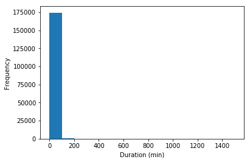

```python
#plot distribution of duration
binsize = 100
bins = np.arange(0, ford_clean['duration_min'].max()+binsize, binsize)
plt.hist(data=ford_clean,x='duration_min',bins=bins)
plt.ylabel('Frequency')
plt.xlabel('Duration (min)');
```

> The distribution has a sharp rightward tilt. To get a better look at the distribution, we might try to zoom into the lower portion of the data.

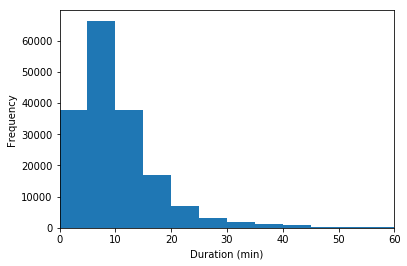

```python
#plot hist of duration
binsize = 5
bins = np.arange(0, ford_clean['duration_min'].max()+binsize, binsize)
plt.hist(data=ford_clean,x='duration_min',bins=bins)
plt.ylabel('Frequency')
plt.xlabel('Duration (min)')
plt.xlim(0,60);
```

The trip duration is mostly concentrated between 0-40 minutes

```python
ford_clean['duration_min'].describe()
```

```
count    174952.000000
mean         11.733379
std          27.370082
min           1.016667
25%           5.383333
50%           8.500000
75%          13.150000
max        1409.133333
Name: duration_min, dtype: float64
```

```python
# check the outlier
1409.133333/60
```

```
23.48555555
```

> Given that it is completely impossible to ride for the entire day, it is evident from the visualization and the summary statistics that there is an outlier. Therefore, we might have to remove this value.

### What is the most popular usage hour?

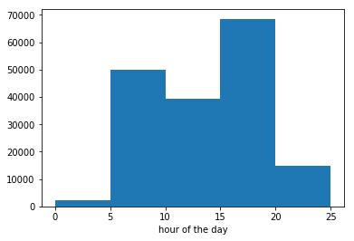

```python
binsize = 5
bins = np.arange(0, ford_clean['start_hour'].max()+binsize, binsize)
plt.hist(data=ford_clean,x='start_hour',bins=bins)
plt.xlabel('hour of the day');
```

Given that this new feature can be considered discrete, it appears that the histogram may not be the best option.

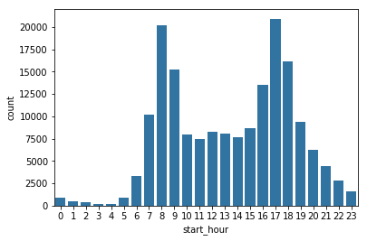

```python
#plot
sb.countplot(data=ford_clean, x='start_hour', color=base_color);
```

> The most usage of the service is high around 8th-9th hour in the morning and 17th-18th hour in the evening. This period is likey to be when workers are heading to their workplace and returning from it.

### what is the age range of bike users?

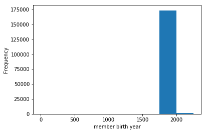

```python
#plot hist of birth year
binsize = 250
bins = np.arange(0, ford_clean['member_birth_year'].max()+binsize, binsize)
plt.hist(data=ford_clean,x='member_birth_year',bins=bins)
plt.xlabel('member birth year')
plt.ylabel('Frequency');
```

```python
ford_clean.member_birth_year.describe()
```

```
count    174952.000000
mean       1984.803135
std          10.118731
min        1878.000000
25%        1980.000000
50%        1987.000000
75%        1992.000000
max        2001.000000
Name: member_birth_year, dtype: float64
```

```python
#check min age

2019-1878
```

```
141
```

```python
#check popular min age range
2019-1980
```

```
39
```

```python
#check popular max age range
2019-1990
```

```
29
```

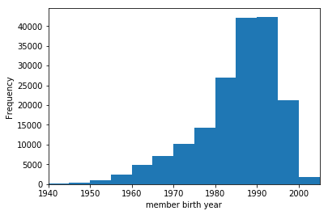

```python
#go deeper on the year
binsize = 5
bins = np.arange(0, ford_clean['member_birth_year'].max()+binsize, binsize)
plt.hist(data=ford_clean,x='member_birth_year',bins=bins)
plt.xlabel('member birth year')
plt.ylabel('Frequency')
plt.xlim(1940,2005);
```

> most of the bike users' age ranges between 29-39. I assume most users of this service are likely to be workers because of the age range as well as the rush hour. The user with 1878 birth year(141years) is likely to be an error. I am guessing it's ;likely to be 1978 instead of 1878 so we might make the minimum value that.

```python
#create barplot
def barplot(data,x,order):
    """
    create a barplot
    """
    base_color=sb.color_palette()[0]

    sb.countplot(data=data,x=x,color=base_color,
            order=order)
    plt.xticks(rotation=15)
    plt.show();
```

### Daily Usage

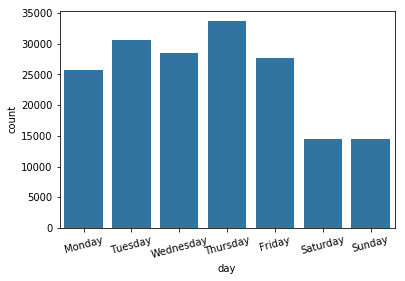

```python
days = ['Monday','Tuesday','Wednesday','Thursday','Friday','Saturday','Sunday']
barplot(ford_clean,'day',days)
```

> The service's usage patterns, which are concentrated on workdays and somewhat low on weekends, confirms some of our presumptions that most users are likely to be employees.This is only an explanation there could be other explanations.

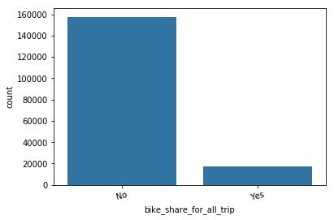

```python
#distribution of bikeshare
order = ford_clean['bike_share_for_all_trip'].value_counts().index
barplot(ford_clean,'bike_share_for_all_trip',order)
```

Most users of the service don't use the service for all their trips

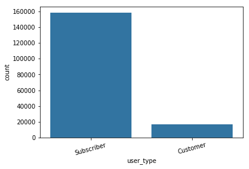

```python
# user type
order = ford_clean['user_type'].value_counts().index
barplot(ford_clean,'user_type',order)
```

There are more subscribers than customers

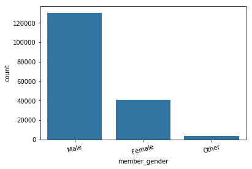

```python
# member gender
order = ford_clean['member_gender'].value_counts().index
barplot(ford_clean,'member_gender',order)
```

more male genders and female

### what is the top ten most popular origin-destination?

```python
def top_ten(data,column,color):
    """
    takes a series and a bar plot of top ten
    """
    series_10 = data[column].value_counts().head(10)
    plot_10 = series_10.plot(kind='barh',color=color);
```

```python
#create orign destination pair

ford_clean['origin-destination'] = ford_clean['start_station_name'] + '-'+ ford_clean['end_station_name']
```

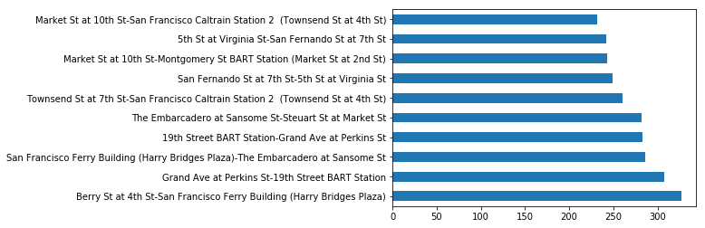

```python
top_ten(ford_clean,'origin-destination',base_color)
```

The most popular origin destination pair is Berry St - San Francisco Ferry Building

### what is the top ten start station name?

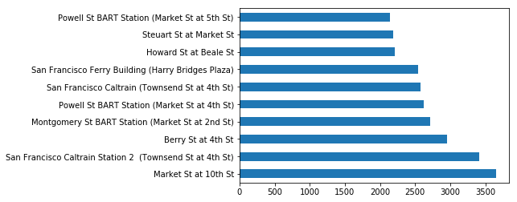

```python
top_ten(ford_clean,'start_station_name',base_color)
```

The most frequented start station is Market St

### what is the top ten end station name?

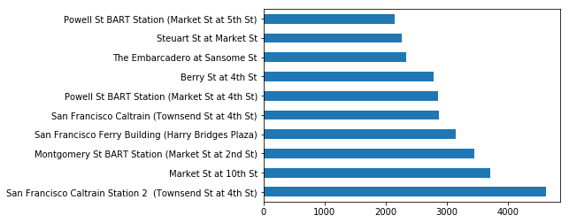

```python
top_ten(ford_clean,'end_station_name',base_color)
```

San Francisco Caltrain Station 2 is the most frequented end destination then followed by Market St.

### Discuss the distribution(s) of your variable(s) of interest. Were there any unusual points? Did you need to perform any transformations?

- The member birth year and duration columns followed a skewed distribution because of outrageous values like duration of 23 hours and age of of 141 so I had to select some parts of the data to see the distribution.

### Of the features you investigated, were there any unusual distributions? Did you perform any operations on the data to tidy, adjust, or change the form of the data? If so, why did you do this?

- There are outliers in the member birth year and duration columns. so I had to select some parts of the data to see the distribution properly.
- I also transformed the duration in seconds to minutes to better interpret the results
- The hour and day values were also extract from the `start time` column to get the daily and hourly usage insight

```python
# Remove outlier in birth year
ford_clean.member_birth_year.replace(1878,1978,inplace=True)
```

```python
ford_clean.member_birth_year.describe()
```

```
count    174952.000000
mean       1984.803706
std          10.115522
min        1900.000000
25%        1980.000000
50%        1987.000000
75%        1992.000000
max        2001.000000
Name: member_birth_year, dtype: float64
```

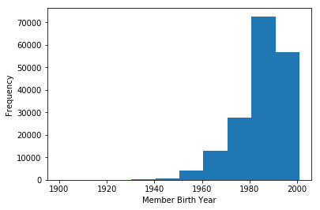

```python
ford_clean.member_birth_year.plot(kind='hist')
plt.xlabel('Member Birth Year');
```

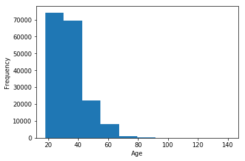

```python
ford_clean.age.plot(kind='hist')
plt.xlabel('Age');
```

This is still slightly skewed but much better than the former one

## Bivariate Exploration

### Daily usage pattern of users

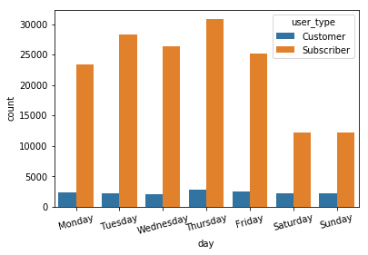

```python
sb.countplot(data = ford_clean, x = 'day', hue = 'user_type',order=days)
plt.xticks(rotation=15);
```

The graph depicts that the usage of the customers don't change daily over time and the usage of the subscribers reduces on weekends

### Hourly usage of different type of users

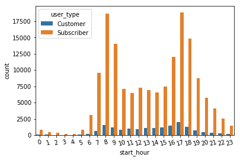

```python
sb.countplot(data = ford_clean, x = 'start_hour', hue = 'user_type')
plt.xticks(rotation=15);
```

The subscribers uses the service more on the rush hour of 8-9 and 17-18. while the customers' usage just flunctuate

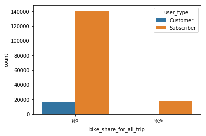

```python
sb.countplot(data = ford_clean, x = 'bike_share_for_all_trip', hue = 'user_type')
plt.xticks(rotation=15);
```

The subscribers are the only user type that uses the service for all trip

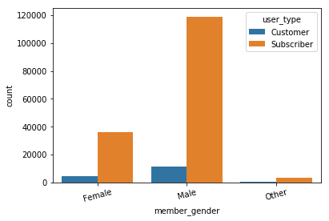

```python
sb.countplot(data = ford_clean, x = 'member_gender', hue = 'user_type')
plt.xticks(rotation=15);
```

in general there are more male that uses the bike share service to female

### Popular origin destination

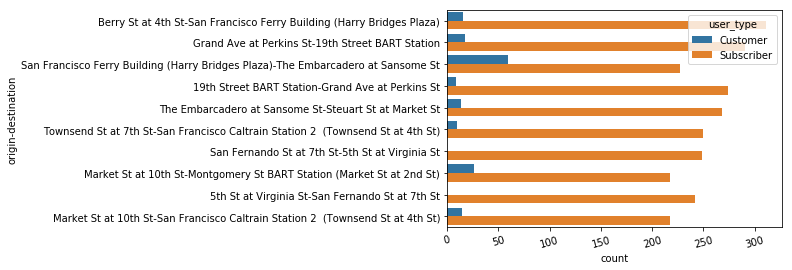

```python
sb.countplot(data = ford_clean, y = 'origin-destination', hue = 'user_type',
            order=ford_clean['origin-destination'].value_counts().iloc[:10].index)
plt.xticks(rotation=15);
```

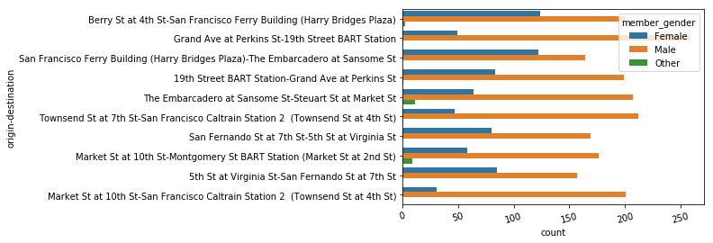

```python
sb.countplot(data = ford_clean, y = 'origin-destination', hue = 'member_gender',
            order=ford_clean['origin-destination'].value_counts().iloc[:10].index)
plt.xticks(rotation=15);
```

The most popular origin-destination pair for the male gender is Grand Ave at Perkins St- !9th Street BART Station, and female gender is Berry St-San Franscisco Ferry Building

### The favorite start station among different types of users

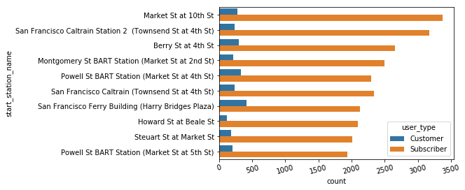

```python
sb.countplot(data = ford_clean, y = 'start_station_name', hue = 'user_type',
            order=ford_clean.start_station_name.value_counts().iloc[:10].index)
plt.xticks(rotation=15);
```

### The favorite end station among different types of users

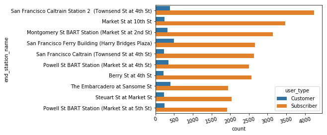

```python
sb.countplot(data = ford_clean, y = 'end_station_name', hue = 'user_type',
            order=ford_clean.end_station_name.value_counts().iloc[:10].index)
plt.xticks(rotation=15);
```

- The most popular start and end station for the customers is San Fransciso Ferry Building (Harry Bridges Plaza). what's happening here?
- The most favorite start station among subscribers is Market St at 10th St and the most popular end station is San Franscisco Caltrain Station 2 (Townsend St at 4th St).

### The duration of usage among age groups

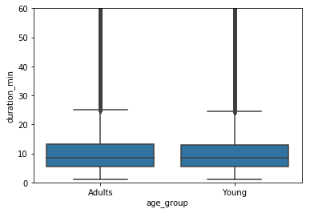

```python
sb.boxplot(data=ford_clean, x='age_group', y='duration_min',color=base_color)
plt.ylim(0,60);
```

### The duration of usage of users

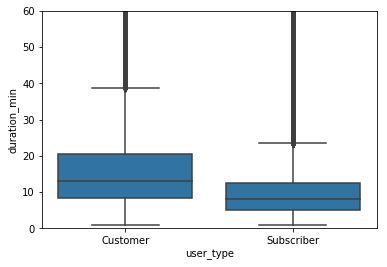

```python
sb.boxplot(data=ford_clean, x='user_type', y='duration_min',color=base_color)
plt.ylim(0,60);
```

Customers typically use services for longer periods of time than subscribers do. The clients utilize it for leisure is probably one of the better answers I can think of. Although we still need to do more research to get the answer, this intriguing insight is enough to get us going right now.

### duration of usage among genders

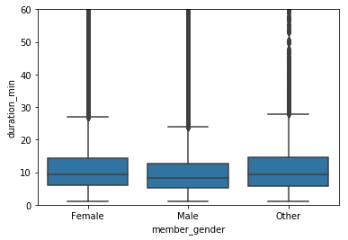

```python
sb.boxplot(data=ford_clean, x='member_gender', y='duration_min',color=base_color)
plt.ylim(0,60);
```

The female gender spends highest duration than the male gender. could this mean more female are customers?

### Talk about some of the relationships you observed in this part of the investigation. How did the feature(s) of interest vary with other features in the dataset?

> - I find it intersting that the customers spends more time(duration_mins) on the service than the subscribers.
> - To also see that the female gender spends more time than the male gender while the male uses the service more in general.

### Did you observe any interesting relationships between the other features (not the main feature(s) of interest)?

> No single customer uses the service for all trips

## Multivariate Exploration

### daily duration of usage among users

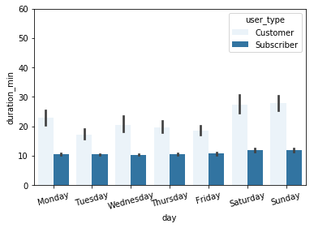

```python
sb.barplot(data=ford_clean, x='day', y='duration_min',color=base_color,hue='user_type',order=days)
plt.ylim(0,60)
plt.xticks(rotation=15);
```

Awesome! This demonstrates and affirms that even though subscribers use the service more frequently, users spend more time using it. The subscribers also spends more time on weekends.

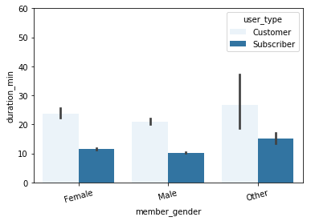

```python
sb.barplot(data=ford_clean, x='member_gender', y='duration_min',color=base_color,hue='user_type')
plt.ylim(0,60)
plt.xticks(rotation=15);
```

### Hourly duration of usage of users

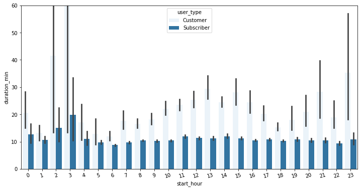

```python
plt.figure(figsize=(12,6))
sb.barplot(data=ford_clean, x='start_hour', y='duration_min',color=base_color,hue='user_type')
plt.ylim(0,60)
plt.xticks(rotation=15);
```

### Duration of usage among users within different age groups

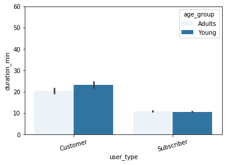

```python
sb.barplot(data=ford_clean, x='user_type', y='duration_min',color=base_color,hue='age_group')
plt.ylim(0,60)
plt.xticks(rotation=15);
```

### Talk about some of the relationships you observed in this part of the investigation. Were there features that strengthened each other in terms of looking at your feature(s) of interest?

> Customers' hourly and daily consumption patterns support the observation that they consume more time overall. Further investigation revealed that their daily and hourly use is often higher.

```python
# Export cleaned dataframe to CSV file


ford_clean.to_csv('ford_clean.csv', index=None)
df = pd.read_csv('ford_clean.csv')
```